# Žene u STEM-u na Zapadnom Balkanu i šire

Tanja

2025-06-05

## Uvod

Ova analiza koristi javno dostupne podatke o udelu žena u STEM obrazovanju i istraživanju na Zapadnom Balkanu, Gruziji i Kazahstanu. Cilj je da se pokaže kako otvoreni podaci i R mogu pomoći u boljem razumevanju rodnih nejednakosti u nauci i tehnologiji, kao i da novinarkama ponude konkretne alate za transparentnu i vizuelno upečatljivu komunikaciju podataka.

## Kako čitati i koristiti podatke

Ovi podaci predstavljaju udeo žena u obrazovanju i istraživanju u oblasti prirodnih nauka, tehnologije, inženjerstva i matematike (STEM). Svaka vrednost u tabeli je procenat žena u odnosu na ukupni broj studenata ili istraživača u datoj oblasti. Tamo gde nije bilo dostupnih podataka, vrednosti su označene kao “NA”.

Kao novinarke, važno je da znate:

- Podaci ne govore sve, ali mogu pokrenuti pitanja i ukazati na trendove.
- Vizualizacije pomažu da se obrasci u podacima uoče brže nego čitanjem tabela.
- Ove vizualizacije vam mogu pomoći da oblikujete priče o rodnoj neravnopravnosti u obrazovanju i nauci.

## Tabelarni prikaz podataka

Iako je dataset mali i lako pregledan u tabelarnom obliku, iz njega se ipak može izvući više informacija vizualizacijom koja ističe obrasce, razlike i moguće odnose između pokazatelja.

```r
data <- read_csv("data/women_in_stem_westbalkan_ge_kz.csv")
kable(data, caption = "Udeo žena u STEM obrazovanju i istraživanju")
```

Udeo žena u STEM obrazovanju i istraživanju

| Country | Engineering_Students_Women(%) | ICT_Students_Women(%) | Natural_Sci_Students_Women(%) | Engineering_Researchers_Women(%) | Natural_Sci_Researchers_Women(%) | Gender_Pay_Gap(%) | Gender_Pay_Gap_Tertiary(%) | Source_Document |
| --- | --- | --- | --- | --- | --- | --- | --- | --- |
| Serbia | 38.2 | 27.4 | 66.1 | 40.4 | 58.1 | 18.0 | NA | CE-W-STEM.docx |
| North Macedonia | 44.5 | 32.4 | 71.3 | 42.9 | 57.0 | 16.3 | 16.3 | CE-W-STEM.docx |
| Bosnia and Herzegovina | 42.5 | 27.2 | 70.1 | 37.0 | 48.7 | NA | NA | CE-W-STEM.docx |
| Montenegro | NA | NA | NA | 35.6 | 49.8 | NA | NA | CE-W-STEM.docx |
| Albania | 31.7 | 35.7 | 70.9 | NA | NA | 10.5 | 14.8 | CE-W-STEM.docx |
| Kosovo | NA | NA | NA | NA | NA | NA | NA | Share_WinSTEM-Edu.docx |
| Georgia | 14.8 | 14.2 | 61.2 | 38.2 | 46.6 | NA | NA | CE-W-STEM.docx |
| Kazakhstan | 27.9 | 32.5 | 70.9 | 44.0 | 53.4 | 32.2 | NA | CE-W-STEM.docx |

## Vizualizacije: vrste i zašto ih koristimo

U ovom dokumentu koristimo dve osnovne vrste grafikona:

1. **Bar grafikon (stubičasti dijagram)**
   - Koristimo ga da prikažemo udeo žena u inženjerskom obrazovanju po zemljama.
   - Bar grafikon je najintuitivniji način da se porede vrednosti između različitih kategorija (npr. država).
2. **Scatter grafikon (raspršeni dijagram)**
   - Koristimo ga da uporedimo dva pokazatelja istovremeno: udeo žena u istraživanju u inženjerstvu i u prirodnim naukama.
   - Scatter grafikon je koristan za otkrivanje odnosa: npr. da li zemlje koje imaju više žena u prirodnim naukama imaju i više žena u inženjerskom istraživanju?

## Vizualizacija 1: Žene među studentima inženjerstva

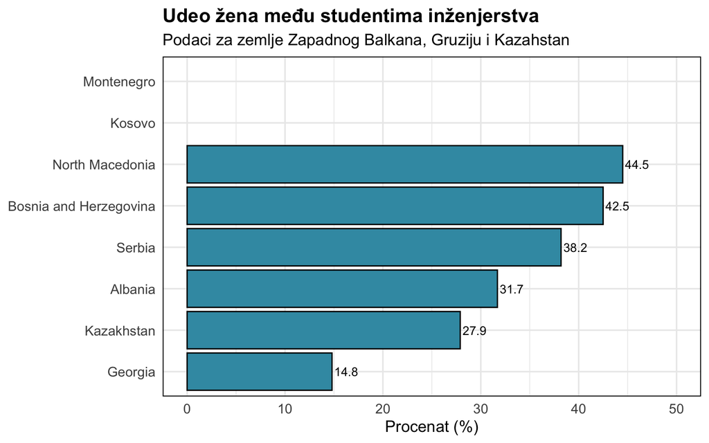

```r
ggplot(data, aes(x = reorder(Country, `Engineering_Students_Women(%)`),
                 y = `Engineering_Students_Women(%)`)) +
  geom_col(fill = "#3B9AB2", color = "black") +
  coord_flip() +
  geom_text(aes(label = round(`Engineering_Students_Women(%)`, 1)), hjust = -0.1, size = 3.5) +
  labs(
    title = "Udeo žena među studentima inženjerstva",
    subtitle = "Podaci za zemlje Zapadnog Balkana, Gruziju i Kazahstan",
    x = NULL,
    y = "Procenat (%)"
  ) +
  theme_minimal(base_size = 13)  +
  theme(panel.border = element_rect(color = "black", fill = NA, linewidth = 0.7)) +
  theme(plot.title = element_text(face = "bold"),
        axis.text.x = element_text(size = 11),
        axis.text.y = element_text(size = 11)) +
  ylim(0, 50)
```

**Tumačenje:** Stubičasti dijagram nam pomaže da odmah vidimo koje zemlje imaju veći ili manji udeo žena među studentima inženjerstva. Zemlje kao što su Severna Makedonija i BiH imaju viši procenat žena, dok Gruzija ima drastično niži. Ovo može biti početna tačka za novinarsko pitanje: *Zašto je u Gruziji tako malo žena u inženjerskim studijama?* Ili: *Šta zemlje poput Makedonije rade drugačije?*

## Vizualizacija 2: Istraživačice u inženjerstvu i prirodnim naukama

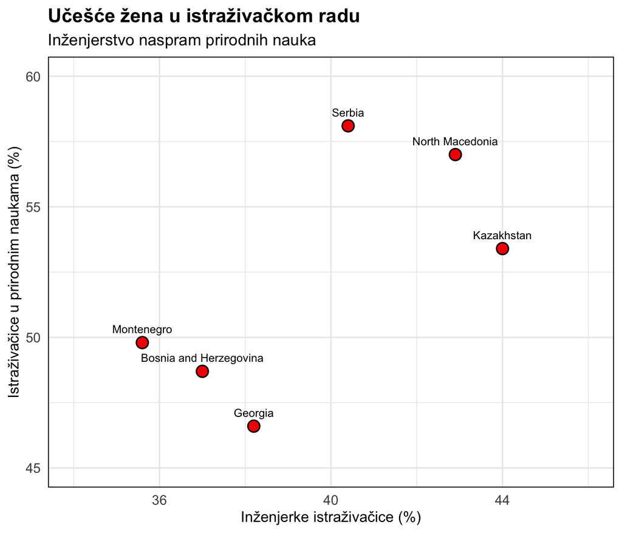

```r
ggplot(data, aes(x = `Engineering_Researchers_Women(%)`,
                 y = `Natural_Sci_Researchers_Women(%)`, label = Country)) +
  geom_point(shape = 21, fill = "#F21A00", color = "black", size = 4, stroke = 0.8)+
  geom_text(vjust = -1.2, size = 3.2) +
  labs(
    title = "Učešće žena u istraživačkom radu",
    subtitle = "Inženjerstvo naspram prirodnih nauka",
    x = "Inženjerke istraživačice (%)",
    y = "Istraživačice u prirodnim naukama (%)"
  ) +
  theme_minimal(base_size = 13) +
  xlim(34, 46) +
  ylim(45, 60) +
  theme(
    plot.title = element_text(face = "bold"),
        axis.text = element_text(size = 11),
        axis.title = element_text(size = 12),
    panel.border = element_rect(color = "black", fill = NA, linewidth = 0.7))
```

**Pitanja za razmišljanje:**

- Da li postoji veza između obrazovanja i istraživačkih pozicija?
- Da li postoji razlika u finansiranju ili zapošljavanju između ovih oblasti?
- Kako se politika zapošljavanja u nauci razlikuje između zemalja?

## Zaključak

Jedna od najvećih prednosti rada sa podacima jeste mogućnost da novinarke jasno i ubedljivo komuniciraju nejednakosti koje bi inače ostale skrivene u tabelama i statističkim izveštajima. Vizualizacije ne samo da olakšavaju razumevanje kompleksnih informacija, već omogućavaju i emocionalni i politički utisak koji podstiče publiku na razmišljanje i akciju.

Vizuelno prikazivanje razlika, kao što su razlike u zastupljenosti žena u obrazovanju ili istraživačkom radu, čini te razlike neosporivim i pristupačnim. Na taj način novinarke mogu:

- Prikazati rodne razlike jasno i upečatljivo;
- Pokazati gde podaci nedostaju i zahtevati njihovu objavu;
- Pozvati institucije na veću transparentnost i odgovornost kroz precizna, vizuelno jasna pitanja i poređenja.

Kroz dve jednostavne vizualizacije u R-u dobili smo osnovu za više novinarskih priča. Podaci nam ne daju sve odgovore, ali nas vode ka pravim pitanjima. Ove metode omogućavaju da:

- Postavite pitanja utemeljena na dokazima;
- Prikažete rodne razlike jasno i vizuelno upečatljivo;
- Pozovete institucije na veću transparentnost i odgovornost.

## Dalji koraci

- Postavite ovu analizu na GitHub uz jednostavno objašnjenje.
- Napravite šablon koji druge novinarke mogu koristiti sa svojim podacima.
- Razvijte priču koristeći kombinaciju brojki i izjava žena iz ovih sektora.
- Uključite javnost u debatu koristeći vizualizacije na društvenim mrežama ili kao infografiku.